# Assignment 6

Thomas Malejko

08 November 2020

## Assignment 6

### Task 1 (National Election Results–*R* )

#### Load the Required Packages

```r
## load required libraries and set global conditions
library(tidyverse)
library(sf)
library(tmap)
library(tmaptools)
library(USAboundaries)
library(tigris)
library(rnaturalearth)
library(osmar)
```

#### Load & Inspect the Required Data

```r
## load the election dataset
electDF <- read_csv('data/countypres_2000-2016.csv')

## confirm its structure
head(electDF)
```

```
## # A tibble: 6 x 11
##    year state state_po county  FIPS office candidate party candidatevotes
##   <dbl> <chr> <chr>    <chr>  <dbl> <chr>  <chr>     <chr>          <dbl>
## 1  2000 Alab~ AL       Autau~  1001 Presi~ Al Gore   demo~           4942
## 2  2000 Alab~ AL       Autau~  1001 Presi~ George W~ repu~          11993
## 3  2000 Alab~ AL       Autau~  1001 Presi~ Ralph Na~ green            160
## 4  2000 Alab~ AL       Autau~  1001 Presi~ Other     <NA>             113
## 5  2000 Alab~ AL       Baldw~  1003 Presi~ Al Gore   demo~          13997
## 6  2000 Alab~ AL       Baldw~  1003 Presi~ George W~ repu~          40872
## # ... with 2 more variables: totalvotes <dbl>, version <dbl>
```

```r
## drop unneeded columns, convert to appropriate d-types, add the zero-
## padding to the FIPS column (should be 5-digits long), and filter to only
## the three election years needed
electDF <- electDF %>%
  select(-c(office, version)) %>%
  filter(year %in% c(2008, 2012, 2016)) %>%
  mutate_at(vars(year, candidatevotes, totalvotes), as.integer) %>%
  mutate_at(vars(FIPS), as.character) %>%
  mutate_at(vars(FIPS), str_pad, width = 5, pad = '0', side = 'left')

## load the unemployment dataset
unempDF <- readxl::read_excel("data/Unemployment.xls",
                              sheet = 'Unemployment Med HH Income',
                              skip = 7)

## retain only columns we need for the unemployment analysis
unempDF <- unempDF %>%
  select(c(FIPStxt, Stabr, area_name, Unemployment_rate_2008, Unemployment_rate_2012,
           Unemployment_rate_2016)) %>%
  rename(FIPS = FIPStxt, State = Stabr, Region = area_name)
```

#### Generate Required Features

```r
## add a feature to the election DF for percent of the vote won
electDF <- electDF %>% mutate(votePercent = candidatevotes/totalvotes)
```

#### Load & Inspect the Required Geospatial Data

```r
## get the US mapping data
counties <- st_as_sf(st_read("data/tl_2019_us_county.shp"))
## merge the geographic data with the election data
electGeo <- electDF %>%
  left_join(counties, by = c('FIPS'='GEOID'))

## get state data for a needed overlay
usMap <- USAboundaries::us_states()

## load lake data--to correctly display the US Map (namely the area around the Great Lakes)
# lakeMap <- st_as_sf(st_read("data/ne_10m_lakes.shp"))
lakeMap <- rnaturalearth::ne_download(scale = 110, type = 'lakes', category = 'physical')
lakeMap <- st_as_sf(lakeMap)
```

#### Generate National Election Choropleths–By County

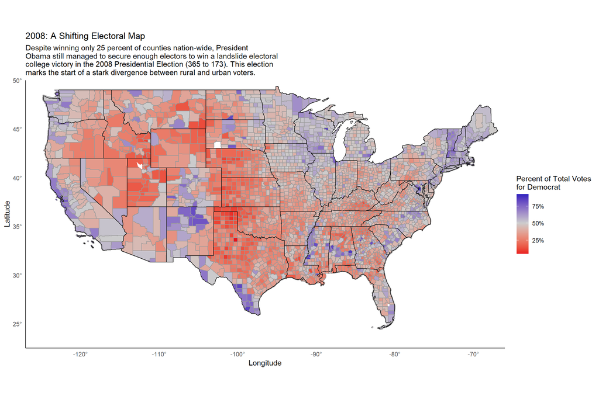

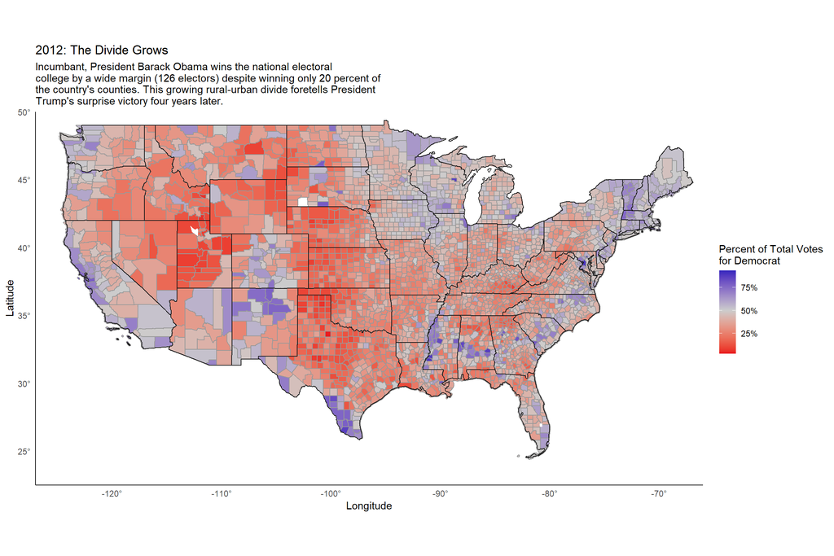

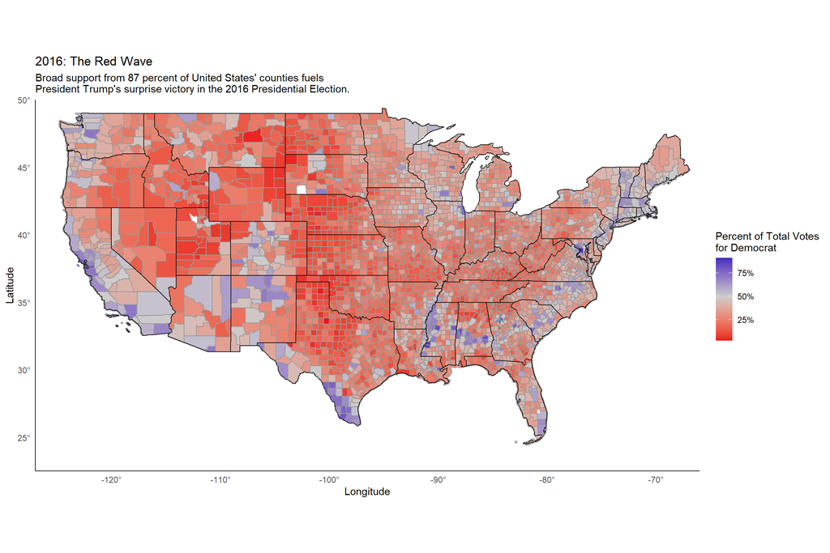

```r
## store the title and subtitles for clean plotting later
titles = c('2008: A Shifting Electoral Map', '2012: The Divide Grows', '2016: The Red Wave')
subtitles = c('Despite winning only 25 percent of counties nation-wide, President \nObama still managed to secure enough electors to win a landslide electoral \ncollege victory in the 2008 Presidential Election (365 to 173). This election \nmarks the start of a stark divergence between rural and urban voters.', 'Incumbant, President Barack Obama wins the national electoral
college by a wide margin (126 electors) despite winning only 20 percent of \nthe country\'s counties. This growing rural-urban divide foretells President \nTrump\'s surprise victory four years later.','Broad support from 87 percent of United States\' counties fuels \nPresident Trump\'s surprise victory in the 2016 Presidential Election.')

## year options
years = c(2008, 2012, 2016)

for (i in c(1, 2, 3)){
  ## modify, filter, and select the data to plot
  p <- electGeo %>%
    filter(year == years[i], party == 'democrat') %>%
    select(FIPS, votePercent, geometry) %>%
    ## generate the base plot
    ggplot() +
    geom_sf(aes(geometry=geometry, fill = votePercent), color = 'grey60') +
    ## customize the fill (low is Republic 'Red', high corresponds to 'Democrat Blue')
    scale_fill_gradient2(low = '#E9141D', mid = 'grey80', high = '#0015BC',
                         midpoint = .5, name = 'Percent of Total Votes\nfor Democrat',
                         labels = scales::percent) +
    ## add the lake data to clean-up plot around the great lakes
    geom_sf(data = lakeMap, aes(geometry = geometry), fill = 'white', color = NA) +
    ## add state boundaries
    geom_sf(data = usMap, aes(geometry = geometry), fill = NA, color = 'grey10') +
    ## trim the coordinates of the map to zoom on CONUS
    coord_sf(xlim = c(-127, -66), ylim = c(22.5, 50) , expand = FALSE) +
    ## relabel the axes to include degree symbol
    scale_x_continuous(labels = scales::label_number(suffix = "°")) +
    scale_y_continuous(labels = scales::label_number(suffix = "°")) +
    ## modify the theme to my taste
    theme_minimal() +
    theme(panel.grid = element_blank(), axis.line  = element_line(color = "grey10")) +
    ## update the axis labels
    xlab('Longitude') +
    ylab('Latitude') +
    ## add the titles
    labs(title = titles[i],
         subtitle = subtitles[i])

  ## print the map to the screen
  print(p)
}
```

The series of choropleths above show the growing polarization in the United States national politic. In 2008, the county-aggregated election results indicate that many counties (43 percent) were closely divided as to their prefered candidate (that is where the percent of votes cast for either candidate was between 40 and 60 percent of county total). By 2012 that number dropped to 34 percent and in the 2016 Presidential Election that number was just 19 percent. This stark divide is particularly distinct amongst rural and suburban counties, which began to vote overwhelming Republican, while more urban counties voted distinctly Democratic.

### Task 2 (State Election/Unemployment Comparison–*Python* )

#### Load Libraries & Set Global Conditions

```python
import pandas as pd
import geopandas as gp
import matplotlib.pyplot as plt
import matplotlib as mpl
from matplotlib import rcParams
rcParams.update({'figure.autolayout': True})

pd.set_option('display.max_columns', 10)
pd.set_option('display.max_rows', None)
pd.set_option('display.max_colwidth', None)
```

#### Create Data Import Functions

```python
def importXLS(filename, sheet_name, skiprows = 0, header = 0):
    '''
    Imports the XLS-formatted data and checks the import quality
    Inputs: filename (str), sheet_name (str or int), skiprows(int), header(int)
    Outputs: DF (Pandas DF)
    '''

    #import the dataset
    DF = pd.read_excel(filename, sheet_name = sheet_name,
                        skiprows = skiprows, header = header)

    #check the quality of the import
    print(DF.head())

    return DF
```

```python
def importData(filename):
    '''
    Imports the data and checks the import quality
    Inputs: filename (str)
    Outputs: DF (Pandas DF)
    '''

    #import the dataset
    DF = pd.read_csv(filename)

    #check the quality of the import
    print(DF.head())

    return DF
```

```python
def importGeo(filename):
    '''
    Imports a geographic dataset
    Inputs: filename (str)
    Outputs: DF (Pandas DF)
    '''
    geoDF = gp.read_file(filename)

    return geoDF
```

#### Create Plotting Function

```python
def generatePlots(geoDF, state, yearRange):
    '''
    Generate a 2x3 plot that compares the unemployment rate with the
    results of the presidential election of the same year.
    Inputs: geoDF, state (str), yearRange (list of strings)
    Outputs: None
    '''
    ## generate the plot
    fig, axs = plt.subplots(2,3, constrained_layout = True, figsize = (13, 10))

    ## populate the plots
    for row in range(2):
        for col in range(3):

            ## set the current axis
            ax = axs[row, col]

            ## create the temporary dataframe based on the year and
            ## state of interest
            temp = unempGeo[(unempGeo['year'] == yearRange[col]) &
                            (unempGeo['Stabr'] == state)]

            ## if the row is 0, then plot unemployment data
            if row == 0:

                ## plot the map in the appropriate position
                rowPlot = temp.plot(column = 'Unemp_Rate', ax = ax,
                                    edgecolor = '#999999', linewidth = .15,
                                    vmin = .01, vmax = .15, cmap = 'YlOrBr',
                                    legend=False)

                ## set the individual plot title
                ax.set_title(yearRange[col] + ' Unemployment Rate', loc = 'left')

            ## if the row is 1, then plot presidential data
            if row == 1:
                ## plot the map in the appropriate position
                rowPlot = temp.plot(column = 'vote_percent', ax = ax,
                                    edgecolor = '#999999', linewidth = .15,
                                    vmin = .1, vmax = .9, cmap = 'RdBu',
                                    legend=False)


                ## set the individual plot title
                ax.set_title(yearRange[col] + ' Presidential Election',
                             loc = 'left')

            ## remove the axis (unnecessary for this sort of graphic)
            ax.set_axis_off()

        ## add the colorbar scale (unemployment)
        if row == 0:
            norm = mpl.colors.Normalize(vmin = 0, vmax = 1)
            ca = fig.colorbar(mpl.cm.ScalarMappable(norm=norm, cmap='YlOrBr'),
                         ax = axs[row, 2], shrink = .4, label = 'Unemployment Rate')

            ## manually set the colorbar-unemployment rate ratio
            ca.ax.set_yticklabels(["{:.0%}".format(i*.15) for i in ca.get_ticks()])

        ## add the colorbar scale (election results)
        if row == 1:
            norm = mpl.colors.Normalize(vmin = .1, vmax = .9)
            cb = fig.colorbar(mpl.cm.ScalarMappable(norm=norm, cmap='RdBu'),
                         ax = axs[row, 2], shrink = .4, label = 'Democratic Candidate Vote')

            cb.ax.set_yticklabels(["{:.0%}".format(i) for i in cb.get_ticks()])

    ## set the title message
    titleMessage = 'Timewise Comparison--The Unemployment Effect on Presidential Election Outcomes (County-Level)'

    ## add the title
    plt.suptitle(titleMessage, x = 0, y = .995, horizontalalignment='left', fontsize = 16,
    fontweight = 'semibold')

    return plt
```

#### Import, Clean, & Reformat Unemployment Data

```python
## load the unemployment data
unempDF = importXLS('data/Unemployment.xls', sheet_name = 'Unemployment Med HH Income',
               skiprows = 7, header = 0)
```

```
##    FIPStxt Stabr           area_name  Rural_urban_continuum_code_2013  \
## 0        0    US       United States                              NaN
## 1     1000    AL             Alabama                              NaN
## 2     1001    AL  Autauga County, AL                              2.0
## 3     1003    AL  Baldwin County, AL                              3.0
## 4     1005    AL  Barbour County, AL                              6.0
##
##    Urban_influence_code_2013  ...  Employed_2019  Unemployed_2019  \
## 0                        NaN  ...    157115247.0        5984808.0
## 1                        NaN  ...      2174483.0          67264.0
## 2                        2.0  ...        25458.0            714.0
## 3                        2.0  ...        94675.0           2653.0
## 4                        6.0  ...         8213.0            324.0
##
##    Unemployment_rate_2019  Median_Household_Income_2018  \
## 0                3.669409                       61937.0
## 1                3.000000                       49881.0
## 2                2.700000                       59338.0
## 3                2.700000                       57588.0
## 4                3.800000                       34382.0
##
##    Med_HH_Income_Percent_of_State_Total_2018
## 0                                        NaN
## 1                                 100.000000
## 2                                 118.959123
## 3                                 115.450773
## 4                                  68.928049
##
## [5 rows x 88 columns]
```

```python
## convert the FIPS Code to a string and add the required padding
unempDF['FIPS'] = unempDF['FIPStxt'].apply(lambda i: str(i).zfill(5))

## retain only the columns of interest
unempDF = unempDF[['FIPS', 'Stabr', 'area_name', 'Unemployment_rate_2008',
                   'Unemployment_rate_2012', 'Unemployment_rate_2016']]

## rename the 'Unemployment Columns' for the melt
unempDF.columns = ['FIPS', 'Stabr', 'area_name', '2008', '2012', '2016']

## melt the dataframe
unempDF = pd.melt(unempDF, id_vars = ['FIPS', 'Stabr', 'area_name'], var_name = 'year',
                  value_name = 'Unemp_Rate')

## convert unemployment rate to a percent
unempDF['Unemp_Rate'] = unempDF['Unemp_Rate'] /100
```

#### Import, Clean, & Reformat Election Data

```python
## load the voter data
voteDF = importData('data/countypres_2000-2016.csv')
```

```
##    year    state state_po   county    FIPS  ...       candidate       party  \
## 0  2000  Alabama       AL  Autauga  1001.0  ...         Al Gore    democrat
## 1  2000  Alabama       AL  Autauga  1001.0  ...  George W. Bush  republican
## 2  2000  Alabama       AL  Autauga  1001.0  ...     Ralph Nader       green
## 3  2000  Alabama       AL  Autauga  1001.0  ...           Other         NaN
## 4  2000  Alabama       AL  Baldwin  1003.0  ...         Al Gore    democrat
##
##   candidatevotes  totalvotes   version
## 0         4942.0       17208  20191203
## 1        11993.0       17208  20191203
## 2          160.0       17208  20191203
## 3          113.0       17208  20191203
## 4        13997.0       56480  20191203
##
## [5 rows x 11 columns]
```

```python
## drop nas that hinder FIPS conversion and padding
voteDF = voteDF.dropna(subset=['FIPS'])

## convert FIPS to the appropriate type
voteDF['FIPS'] = voteDF['FIPS'].apply(lambda i: str(int(i)).zfill(5))

## convert year to string object for appropriate merging
voteDF['year'] = voteDF.astype(str)

## generate the vote percentage feature
voteDF['vote_percent'] = voteDF['candidatevotes'] / voteDF['totalvotes']

## filter the dataset to only the columns and years of interest
voteDF = voteDF[['year', 'FIPS', 'party', 'vote_percent']]

voteDF = voteDF[(voteDF['year'].isin(['2008', '2012', '2016'])) &
                (voteDF['party'] == 'democrat')]
```

#### Import the County, Geospatial Data

```python
## load the county geographic data
usCounties = importGeo('data/tl_2019_us_county.shp')
```

#### Merge the Datasets into a Single, Analytic Dataset

```python
## merge the vote and unemployment data
unempDF = unempDF.merge(voteDF, how = 'left', on = ['FIPS', 'year'])

## merge the unemployment and geo data
unempGeo = usCounties.merge(unempDF, left_on = 'GEOID', right_on = 'FIPS')

## filter to the three states in question
unempGeo = unempGeo[unempGeo['Stabr'].isin(['CA', 'TX', 'PA'])]
```

#### Generate the California Map

*The RStudio & Reticulate set-up was unable to replicate the facetted plots seen below (resulting in clipping and distortion of one map in each row and the colorbar). Much time was spent troubleshooting various techniques to prevent this issue, including various combinations of ‘figsize’, ‘constrained_layout’, and ‘tight_layout’ within the Python code, in addition to, modifications to the RMarkdown knit settings to no avail. Consquently, the plots below were generated and saved from Spyder/matplotlib and imported as a .png in this RMarkdown file. The code above–if run from RMarkdown–will generate the same plots but with the distortion noted above.*

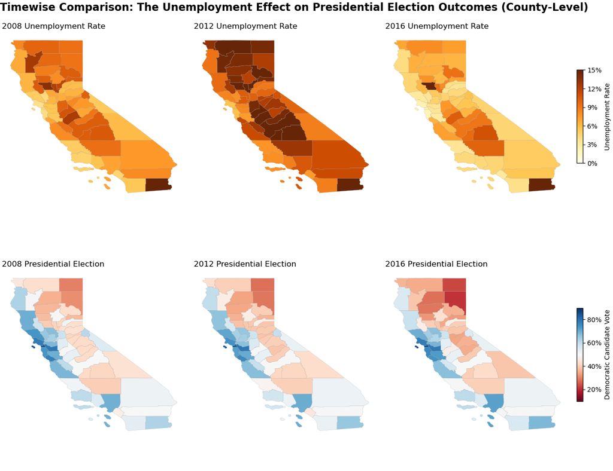

```python
p = generatePlots(unempGeo, 'CA', ['2008', '2012', '2016'])
# p.savefig('ANLY503_A7_CAPlot.png')
```

#### Generate the Texas Map

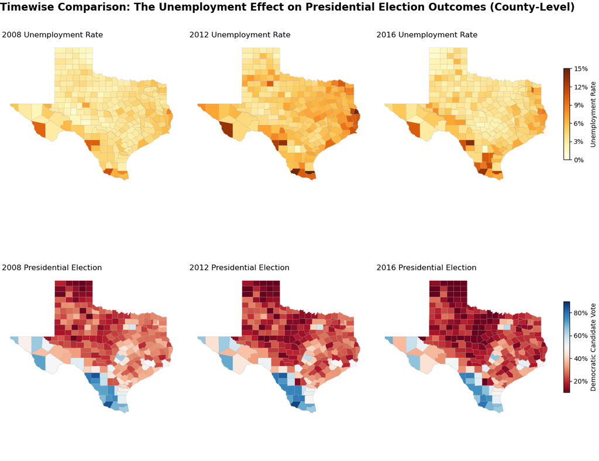

```python
p = generatePlots(unempGeo, 'TX', ['2008', '2012', '2016'])
# p.savefig('ANLY503_A7_TXPlot.png')
```

While Texans bared the Great Recession better than most, residents of border counties fared far worse than their inland counterparts. Consquently, you can observe a slight shift away from supporting the Democratic Candidate for President between the 2012-2016 Presidential Elections especially in the areas around Laredo and Brownsville.

#### Generate the Pennslyvania Map

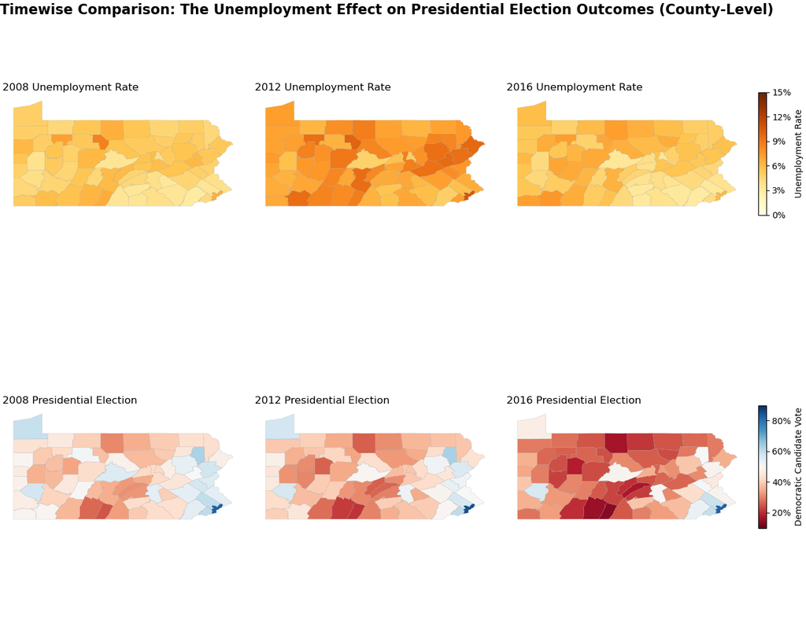

```python
##### Generate the Plots #####
p = generatePlots(unempGeo, 'PA', ['2008', '2012', '2016'])
# p.savefig('ANLY503_A7_PAPlot.png')
```